# **Instacart Grocery Basket Analysis - Project**

### **Part II**

**TABLE OF CONTENTS**

- Libraries
- Dataframes
- Data description
- Key questions
- Export

# Libraries

```python
import pandas as pd
import numpy as np
import os
import matplotlib.pyplot as plt
import seaborn as sns
import scipy
```

# Dataframes

```python
path = r'C:\Users\tomis\Documents\InstaCart Basket Analysis'
df = pd.read_pickle(os.path.join(path, '02 Data', 'Prepared Data', 'dataframe_combined.pkl'))
df_dep = pd.read_pickle(os.path.join(path, '02 Data', 'Prepared Data', 'departments.pkl'))
```

# Data description

```python
# df dataframe (dataframe_combined) check

df.info()
```

```
<class 'pandas.core.frame.DataFrame'>
Int64Index: 30964564 entries, 0 to 32404854
Data columns (total 40 columns):
 #   Column                  Dtype
---  ------                  -----
 0   order_id                int32
 1   user_id                 int32
 2   order_number            int8
 3   orders_day_of_week      int8
 4   order_hour_of_day       int8
 5   days_since_prior_order  float32
 6   new_customer            bool
 7   product_id              int32
 8   add_to_cart_order       int32
 9   reordered               int8
```

[output cut: 32 more lines]

```python
df.shape
```

```
(30964564, 40)
```

```python
df.head()
```

|  | order_id | user_id | order_number | orders_day_of_week | order_hour_of_day | days_since_prior_order | new_customer | product_id | add_to_cart_order | reordered | ... | family_status | income | region | exclusion_flag | age_category | marital_category | family_category | income_category | profile_category | work_shift |
| --- | --- | --- | --- | --- | --- | --- | --- | --- | --- | --- | --- | --- | --- | --- | --- | --- | --- | --- | --- | --- | --- |
| 0 | 2539329 | 1 | 1 | 2 | 8 | NaN | True | 196 | 1 | 0 | ... | married | 40423 | South | 1 | middle-aged adult | married | parent | low income | 22 | III. shift |
| 1 | 2398795 | 1 | 2 | 3 | 7 | 15.0 | False | 196 | 1 | 1 | ... | married | 40423 | South | 1 | middle-aged adult | married | parent | low income | 22 | III. shift |
| 2 | 473747 | 1 | 3 | 3 | 12 | 21.0 | False | 196 | 1 | 1 | ... | married | 40423 | South | 1 | middle-aged adult | married | parent | low income | 22 | I. shift |
| 3 | 2254736 | 1 | 4 | 4 | 7 | 29.0 | False | 196 | 1 | 1 | ... | married | 40423 | South | 1 | middle-aged adult | married | parent | low income | 22 | III. shift |
| 4 | 431534 | 1 | 5 | 4 | 15 | 28.0 | False | 196 | 1 | 1 | ... | married | 40423 | South | 1 | middle-aged adult | married | parent | low income | 22 | I. shift |

5 rows × 40 columns

```python
df.tail()
```

|  | order_id | user_id | order_number | orders_day_of_week | order_hour_of_day | days_since_prior_order | new_customer | product_id | add_to_cart_order | reordered | ... | family_status | income | region | exclusion_flag | age_category | marital_category | family_category | income_category | profile_category | work_shift |
| --- | --- | --- | --- | --- | --- | --- | --- | --- | --- | --- | --- | --- | --- | --- | --- | --- | --- | --- | --- | --- | --- |
| 32404850 | 3308056 | 106143 | 22 | 4 | 20 | 10.0 | False | 19675 | 1 | 1 | ... | single | 53755 | West | 1 | young adult | single | nonparent | middle income | 02 | II. shift |
| 32404851 | 2988973 | 106143 | 23 | 2 | 22 | 5.0 | False | 19675 | 1 | 1 | ... | single | 53755 | West | 1 | young adult | single | nonparent | middle income | 02 | II. shift |
| 32404852 | 930 | 106143 | 24 | 6 | 12 | 4.0 | False | 19675 | 1 | 1 | ... | single | 53755 | West | 1 | young adult | single | nonparent | middle income | 02 | I. shift |
| 32404853 | 467253 | 106143 | 25 | 6 | 16 | 7.0 | False | 19675 | 1 | 1 | ... | single | 53755 | West | 1 | young adult | single | nonparent | middle income | 02 | I. shift |
| 32404854 | 156685 | 106143 | 26 | 4 | 23 | 5.0 | False | 19675 | 1 | 1 | ... | single | 53755 | West | 1 | young adult | single | nonparent | middle income | 02 | II. shift |

5 rows × 40 columns

```python
# df_dep dataframe (departments) check

df_dep.info()
```

```
<class 'pandas.core.frame.DataFrame'>
Index: 21 entries, 1 to 21
Data columns (total 1 columns):
 #   Column      Non-Null Count  Dtype
---  ------      --------------  -----
 0   department  21 non-null     object
dtypes: object(1)
memory usage: 336.0+ bytes
```

```python
df_dep.shape
```

```
(21, 1)
```

```python
df_dep.head()
```

| department_id | department |
| --- | --- |
| 1 | frozen |
| 2 | other |
| 3 | bakery |
| 4 | produce |
| 5 | alcohol |

# Key questions

### Busiest days of the week

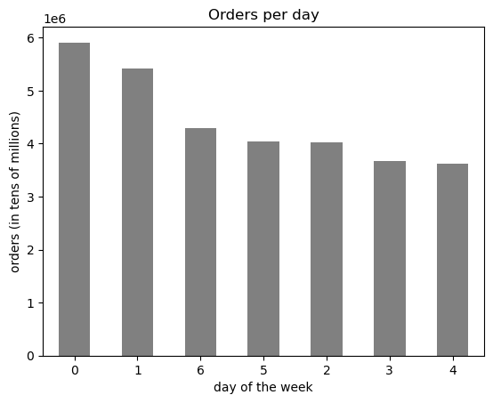

```python
busiest_days = df['orders_day_of_week'].value_counts().plot.bar(rot = 'horizontal', color = 'gray', xlabel = 'day of the week', ylabel = 'orders (in tens of millions)', title= 'Orders per day')
```

Most orders are placed on weekends, with Saturday being the busiest day. Least orders are placed on Wednesday.

### Busiest hours of the day

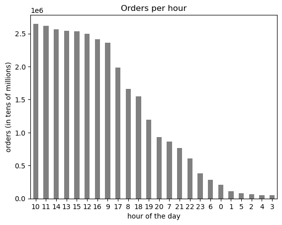

```python
busiest_hours = df['order_hour_of_day'].value_counts().plot.bar(rot = 'horizontal', color = 'gray', xlabel = 'hour of the day', ylabel = 'orders (in tens of millions)', title= 'Orders per hour')
```

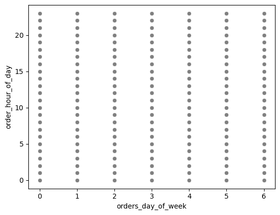

```python
sctpl_time = sns.scatterplot(x = 'orders_day_of_week', y = 'order_hour_of_day', data = df, color = 'gray')
```

Most order are placed between 9 a.m. and 4 p.m. with 10-11 a.m. being the busiest period of the day. Least order are between midnight and 6 a.m.

### Are there particular times of the day when people spend the most money?

```python
df.groupby('order_hour_of_day').agg({'order_id': ['count'], 'prices': ['mean', 'sum']})
```

| order_hour_of_day | order_id count | prices mean | prices sum |
| --- | --- | --- | --- |
| 0 | 208042 | 7.811935 | 1.625008e+06 |
| 1 | 109621 | 7.806721 | 8.556556e+05 |
| 2 | 65691 | 7.803857 | 5.125339e+05 |
| 3 | 48796 | 7.829994 | 3.819784e+05 |
| 4 | 50763 | 7.842190 | 3.980147e+05 |
| 5 | 84418 | 7.831289 | 6.609686e+05 |
| 6 | 281013 | 7.819828 | 2.197137e+06 |
| 7 | 863213 | 7.821447 | 6.750582e+06 |
| 8 | 1659110 | 7.789950 | 1.292248e+07 |
| 9 | 2363611 | 7.752057 | 1.832018e+07 |
| 10 | 2649744 | 7.748280 | 2.052780e+07 |
| 11 | 2614880 | 7.770356 | 2.031521e+07 |
| 12 | 2495795 | 7.790153 | 1.943945e+07 |
| 13 | 2539276 | 7.792976 | 1.978569e+07 |
| 14 | 2567903 | 7.802532 | 2.003313e+07 |
| 15 | 2535966 | 7.805518 | 1.979137e+07 |
| 16 | 2413681 | 7.802230 | 1.882868e+07 |
| 17 | 1982345 | 7.807258 | 1.547393e+07 |
| 18 | 1551184 | 7.809190 | 1.211138e+07 |
| 19 | 1193878 | 7.794600 | 9.304110e+06 |
| 20 | 930909 | 7.800477 | 7.260388e+06 |
| 21 | 763111 | 7.805775 | 5.955876e+06 |
| 22 | 607060 | 7.816767 | 4.744754e+06 |
| 23 | 384554 | 7.796598 | 2.997909e+06 |

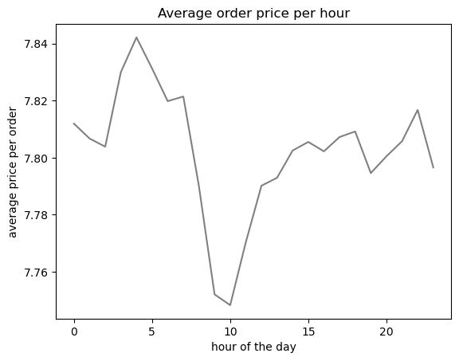

```python
avg_price_per_hour = df.groupby(df['order_hour_of_day'])['prices'].mean().plot.line(color = ['gray'], xlabel = 'hour of the day', ylabel = 'average price per order', title='Average order price per hour')
```

On average, our customers spend slightly more in the early hours, between midnight and 6 a.m. when compared to the rest of the day.

### Simpler price range groupings to help marketing and sales

```python
df.groupby('department_id').agg({'prices': ['mean', 'min', 'max']})
```

| department_id | prices mean | prices min | prices max |
| --- | --- | --- | --- |
| 1 | 7.733725 | 1.0 | 15.0 |
| 2 | 6.961995 | 1.1 | 15.0 |
| 3 | 7.857482 | 1.0 | 15.0 |
| 4 | 7.980348 | 1.0 | 15.0 |
| 5 | 8.150699 | 1.0 | 15.0 |
| 6 | 7.678797 | 1.0 | 15.0 |
| 7 | 7.682556 | 1.0 | 15.0 |
| 8 | 7.887488 | 1.0 | 15.0 |
| 9 | 7.349370 | 1.0 | 15.0 |
| 10 | 8.346919 | 1.4 | 14.1 |
| 11 | 7.998744 | 1.0 | 15.0 |
| 12 | 16.300034 | 8.0 | 25.0 |
| 13 | 8.014482 | 1.0 | 20.0 |
| 14 | 8.031647 | 1.0 | 14.9 |
| 15 | 7.546660 | 1.0 | 15.0 |
| 16 | 8.336372 | 1.0 | 15.0 |
| 17 | 7.379951 | 1.0 | 15.0 |
| 18 | 7.634399 | 1.0 | 15.0 |
| 19 | 4.275555 | 1.6 | 7.0 |
| 20 | 7.783347 | 1.0 | 15.0 |
| 21 | 8.660655 | 1.0 | 15.0 |

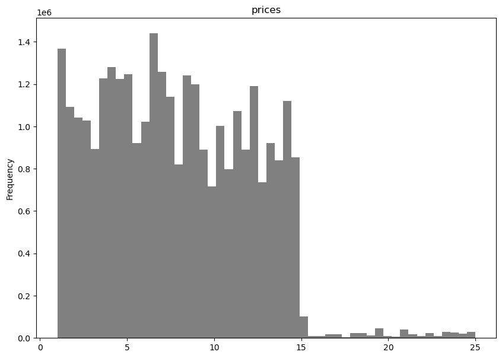

```python
prices_hist = df['prices'].plot.hist(bins = 50, color = ['gray'], figsize = (10,7), title = 'prices')
```

```python
df['price_range_loc'].value_counts()
```

```
Mid-range product     20891771
Low-range product      9674840
High-range product      397953
Name: price_range_loc, dtype: int64
```

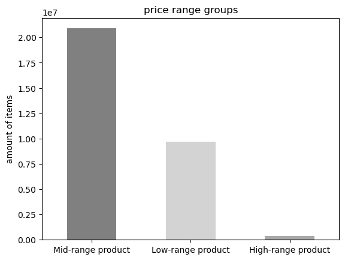

```python
bar_price = df['price_range_loc'].value_counts().plot.bar(title = 'price range groups' , ylabel='amount of items', color = ['gray', 'lightgray', 'darkgray'], rot = 'horizontal')
```

```python
pd.crosstab(df['department_id'], df['price_range_loc'])
```

| price_range_loc department_id | High-range product | Low-range product | Mid-range product |
| --- | --- | --- | --- |
| 1 | 0 | 647617 | 1474114 |
| 2 | 0 | 15259 | 19152 |
| 3 | 0 | 274986 | 845842 |
| 4 | 0 | 2585708 | 6493565 |
| 5 | 0 | 33046 | 111581 |
| 6 | 0 | 73203 | 182788 |
| 7 | 0 | 814697 | 1757204 |
| 8 | 0 | 28165 | 64895 |
| 9 | 0 | 284346 | 537790 |
| 10 | 0 | 1181 | 32270 |
| 11 | 0 | 123874 | 300432 |
| 12 | 392855 | 0 | 281926 |
| 13 | 221 | 504521 | 1277963 |
| 14 | 0 | 209185 | 461665 |
| 15 | 0 | 281711 | 730363 |
| 16 | 4877 | 1370908 | 3801397 |
| 17 | 0 | 245070 | 454787 |
| 18 | 0 | 121484 | 288908 |
| 19 | 0 | 1742143 | 1024263 |
| 20 | 0 | 299220 | 704614 |
| 21 | 0 | 18516 | 46252 |

### Which departments have the highest frequency of product orders?

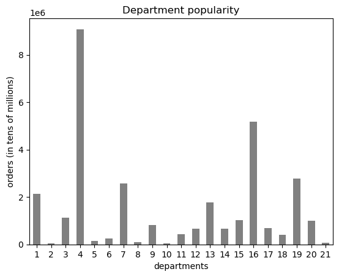

```python
dep_bar = df.groupby('department_id').agg({'order_id': ['count']}).plot.bar(rot = 'horizontal', color = 'gray', legend = False, xlabel = 'departments', ylabel = 'orders (in tens of millions)', title='Department popularity')
```

```python
df_dep
```

| department_id | department |
| --- | --- |
| 1 | frozen |
| 2 | other |
| 3 | bakery |
| 4 | produce |
| 5 | alcohol |
| 6 | international |
| 7 | beverages |
| 8 | pets |
| 9 | dry goods pasta |
| 10 | bulk |
| 11 | personal care |
| 12 | meat seafood |
| 13 | pantry |
| 14 | breakfast |
| 15 | canned goods |
| 16 | dairy eggs |
| 17 | household |
| 18 | babies |
| 19 | snacks |
| 20 | deli |
| 21 | missing |

```python
df.groupby('department_id').agg({'days_since_prior_order': ['mean']})
```

| department_id | days_since_prior_order mean |
| --- | --- |
| 1 | 11.413880 |
| 2 | 10.624647 |
| 3 | 10.808401 |
| 4 | 10.574120 |
| 5 | 10.006659 |
| 6 | 10.963732 |
| 7 | 10.768469 |
| 8 | 11.593531 |
| 9 | 11.440362 |
| 10 | 9.880211 |
| 11 | 11.256240 |
| 12 | 11.123647 |
| 13 | 10.835976 |
| 14 | 11.001313 |
| 15 | 11.316872 |
| 16 | 10.709201 |
| 17 | 11.649305 |
| 18 | 9.780844 |
| 19 | 10.671110 |
| 20 | 11.051389 |
| 21 | 9.869552 |

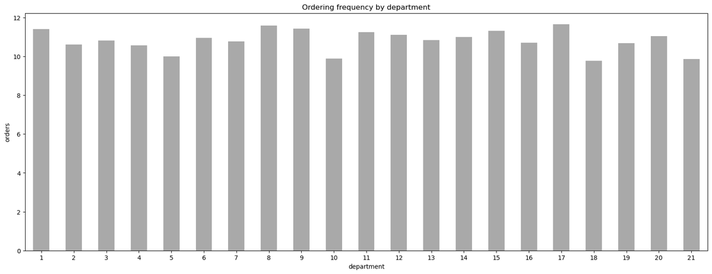

```python
dep_freq = df.groupby('department_id').agg({'days_since_prior_order': ['mean']}).plot.bar(title='Ordering frequency by department', xlabel='department', ylabel='orders', figsize = (20,7), color='darkgray', legend = False, rot='horizontal')
```

Overall, items from the 'produce' (9079273) and 'dairy eggs' (5177182) departments have been ordered most times, but items from the 'baby', 'bulk' and 'missing' departments most frequent.

### What’s the distribution among users in regards to their brand loyalty - how often do they return to Instacart?

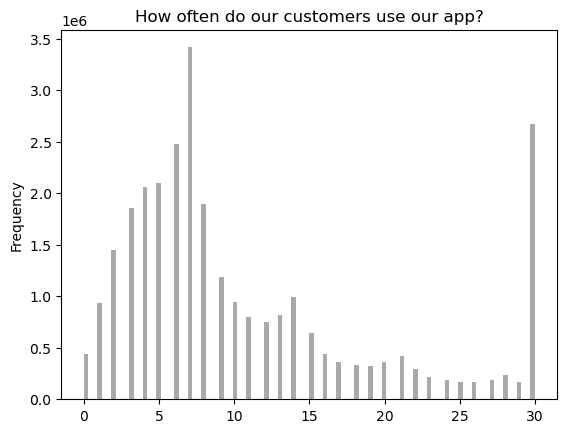

```python
loyalty_distribution = df['days_since_prior_order'].plot.hist(bins = 100, color = 'darkgray', title='How often do our customers use our app?')
```

```python
df.groupby('loyalty_flag')['user_id'].nunique()
```

```
loyalty_flag
Loyal customer      17017
New customer        68750
Regular customer    76864
Name: user_id, dtype: int64
```

Many of our customers often use our app and order on a weekly basis.

### Are there differences in ordering habits based on a customer’s loyalty status?

```python
df.groupby('loyalty_flag').agg({'days_since_prior_order': ['mean']})
```

| loyalty_flag | days_since_prior_order mean |
| --- | --- |
| Loyal customer | 6.026656 |
| New customer | 17.598692 |
| Regular customer | 12.155136 |

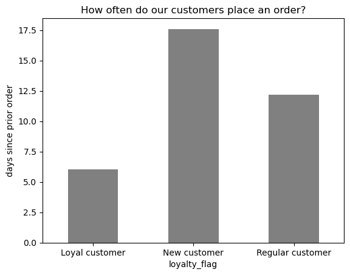

```python
loyalty_freq = df.groupby('loyalty_flag').agg({'days_since_prior_order': ['mean']}).plot.bar(title='How often do our customers place an order?', rot='horizontal', ylabel='days since prior order', color='gray', legend=False)
```

Yes, loyal customers order more frequently than the rest of the customers.

### Are there differences in ordering habits based on a customer’s region?

```python
df.groupby('region').agg({'days_since_prior_order': ['mean'], 'prices': ['mean']})
```

| region | days_since_prior_order mean | prices mean |
| --- | --- | --- |
| Midwest | 10.892735 | 7.792318 |
| Northeast | 10.774220 | 7.781441 |
| South | 10.814227 | 7.794439 |
| West | 10.754622 | 7.790308 |

There is a very small difference in ordering frequency based on customer's region.

### Is there a connection between age and family status in terms of ordering habits?

```python
df.groupby(['age_category', 'family_status']).agg({'days_since_prior_order': ['mean'],'prices': ['mean'] })
```

| age_category | family_status | days_since_prior_order mean | prices mean |
| --- | --- | --- | --- |
| middle-aged adult | divorced/widowed | 10.960488 | 7.842525 |
|  | married | 10.827522 | 7.790868 |
|  | single | 10.754059 | 7.788582 |
| older adult | divorced/widowed | 10.741025 | 7.799175 |
|  | married | 10.808885 | 7.795131 |
| young adult | living with parents and siblings | 10.750995 | 7.800604 |
|  | married | 10.826506 | 7.776981 |
|  | single | 10.946888 | 7.772441 |

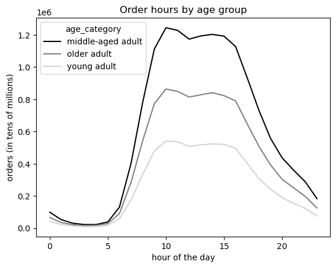

```python
age_ordering_time = pd.crosstab(df['order_hour_of_day'], df['age_category']).plot.line(color = ['black', 'gray', 'lightgray'], xlabel = 'hour of the day', ylabel = 'orders (in tens of millions)', title='Order hours by age group')
```

There is no noticable connection between age and family status in terms of ordering frequency or time in day the orders take place.

### What different classifications does the demographic information suggest? Age? Income? Certain types of goods? Family status?

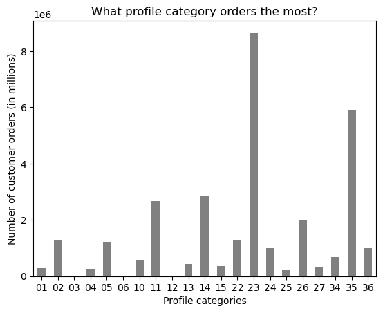

```python
bar_profile = df['profile_category'].value_counts().sort_index().plot.bar(color= 'gray', xlabel = 'Profile categories', ylabel = 'Number of customer orders (in millions)', rot = 'horizontal', title='What profile category orders the most?')
```

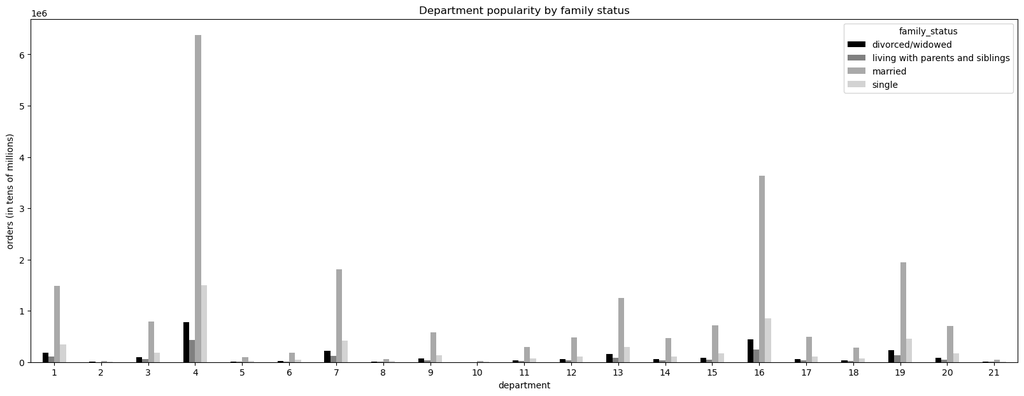

```python
family_status_dep = pd.crosstab(df['department_id'], df['family_status']).plot.bar(figsize = (20,7), rot = 'horizontal', color = ['black', 'gray', 'darkgray', 'lightgray'], xlabel = 'department', ylabel = 'orders (in tens of millions)', title = 'Department popularity by family status')
```

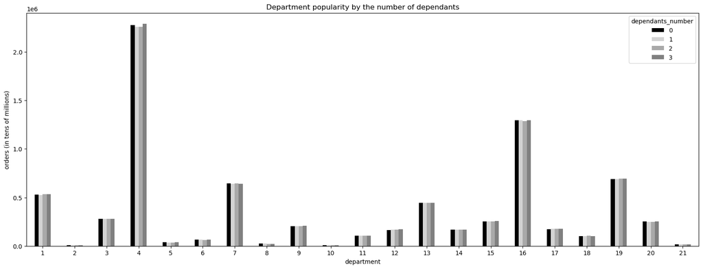

```python
dep_dep =pd.crosstab(df['department_id'], df['dependants_number']).plot.bar(figsize = (20,7), rot = 'horizontal', color = ['black', 'lightgray', 'darkgray', 'gray'], xlabel = 'department', ylabel = 'orders (in tens of millions)', title='Department popularity by the number of dependants')
```

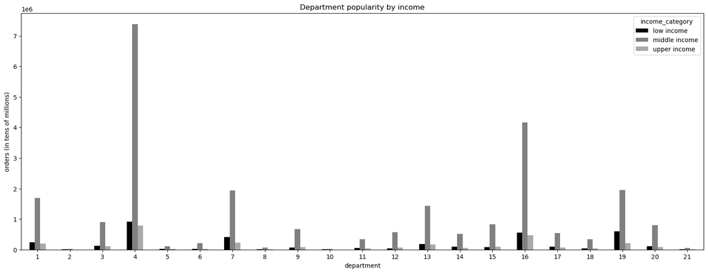

```python
income_dep = pd.crosstab(df['department_id'], df['income_category']).plot.bar(figsize = (20,7), rot = 'horizontal', color = ['black', 'gray', 'darkgray'], xlabel = 'department', ylabel = 'orders (in tens of millions)', title='Department popularity by income')
```

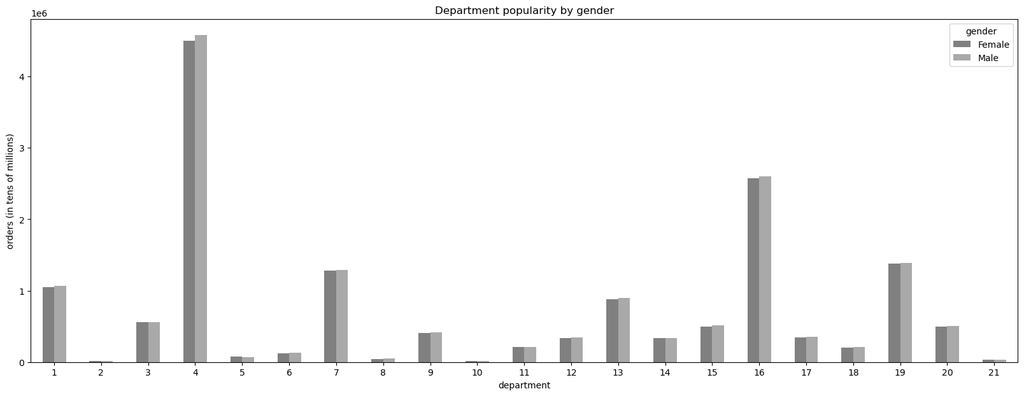

```python
gender_dep = pd.crosstab(df['department_id'], df['gender']).plot.bar(figsize = (20,7), rot = 'horizontal', color = ['gray', 'darkgray'], xlabel = 'department', ylabel = 'orders (in tens of millions)', title='Department popularity by gender')
```

Most of our customers fall into two categories:

- 23 - middle-aged adult, married, parent, middle income
- 35 - older adult, married, parent, middle income

### What differences can you find in ordering habits of different customer profiles? Consider the price of orders, the frequency of orders, the products customers are ordering, and anything else you can think of.

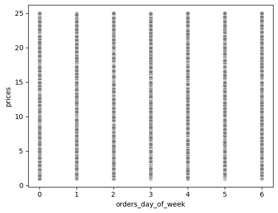

```python
sctpl = sns.scatterplot(x = 'orders_day_of_week', y = 'prices', data = df, color = 'gray')
```

```python
df.groupby(['profile_category']).agg({'prices': ['mean'], 'days_since_prior_order': ['mean']})
```

| profile_category | prices mean | days_since_prior_order mean |
| --- | --- | --- |
| 01 | 6.996967 | 11.132957 |
| 02 | 7.945729 | 10.904235 |
| 03 | 7.715315 | 11.090675 |
| 04 | 7.019078 | 11.284382 |
| 05 | 7.959813 | 10.655309 |
| 06 | 7.950671 | 9.499601 |
| 10 | 6.987693 | 11.134749 |
| 11 | 7.942319 | 10.765913 |
| 12 | 7.759674 | 10.487613 |
| 13 | 6.745749 | 10.989375 |
| 14 | 7.929829 | 10.769935 |
| 15 | 7.918361 | 10.406620 |
| 22 | 6.753661 | 11.200998 |
| 23 | 7.927244 | 10.773066 |
| 24 | 7.937580 | 10.823698 |
| 25 | 6.523318 | 11.179020 |
| 26 | 7.917624 | 10.713081 |
| 27 | 7.931087 | 10.623575 |
| 34 | 6.509172 | 11.127441 |
| 35 | 7.916582 | 10.804039 |
| 36 | 7.952266 | 10.621200 |

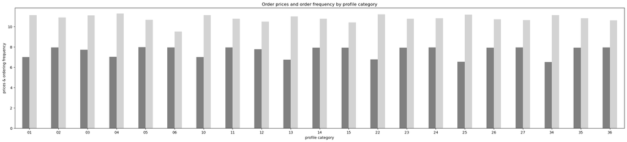

```python
price_dspo_mean = df.groupby(['profile_category']).agg({'prices': ['mean'], 'days_since_prior_order': ['mean']}).plot.bar(figsize = (30,6), color = ['gray', 'lightgray'], rot = 'horizontal', xlabel = 'profile category', ylabel='prices & ordering frequency', title='Order prices and order frequency by profile category', legend=False)
```

```python
df.groupby(['income_category']).agg({'prices': ['mean'], 'days_since_prior_order': ['mean']})
```

| income_category | prices mean | days_since_prior_order mean |
| --- | --- | --- |
| low income | 6.766241 | 11.152222 |
| middle income | 7.928420 | 10.775523 |
| upper income | 7.936951 | 10.662901 |

# Export

```python
# exporting visualizations

busiest_days.figure.savefig(os.path.join(path, '04 Analysis','Visualizations', 'busiest days.png'))
```

```python
busiest_hours.figure.savefig(os.path.join(path, '04 Analysis','Visualizations', 'busiest hours.png'))
```

```python
avg_price_per_hour.figure.savefig(os.path.join(path, '04 Analysis','Visualizations', 'average price per hour.png'))
```

```python
prices_hist.figure.savefig(os.path.join(path, '04 Analysis','Visualizations', 'prices histogram.png'))
```

```python
loyalty_distribution.figure.savefig(os.path.join(path, '04 Analysis','Visualizations', 'loyalty distribution.png'))
```

```python
age_ordering_time.figure.savefig(os.path.join(path, '04 Analysis','Visualizations', 'ordering hour per age.png'))
```

```python
bar_profile.figure.savefig(os.path.join(path, '04 Analysis','Visualizations', 'profile category.png'))
```

```python
family_status_dep.figure.savefig(os.path.join(path, '04 Analysis','Visualizations', 'family status and departments.png'))
```

```python
dep_dep.figure.savefig(os.path.join(path, '04 Analysis','Visualizations', 'dependants number and departments.png'))
```

```python
income_dep.figure.savefig(os.path.join(path, '04 Analysis','Visualizations', 'income and departments.png'))
```

```python
gender_dep.figure.savefig(os.path.join(path, '04 Analysis','Visualizations', 'gender and departments.png'))
```

```python
sctpl.figure.savefig(os.path.join(path, '04 Analysis','Visualizations', 'hours_prices scatterplot.png'))
```

```python
sctpl_time.figure.savefig(os.path.join(path, '04 Analysis','Visualizations', 'time scatterplot.png'))
```

```python
dep_bar.figure.savefig(os.path.join(path, '04 Analysis','Visualizations', 'departments bar.png'))
```

```python
bar_price.figure.savefig(os.path.join(path, '04 Analysis','Visualizations', 'price groups.png'))
```

```python
dep_freq.figure.savefig(os.path.join(path, '04 Analysis','Visualizations', 'order frequency by department.png'))
```

```python
loyalty_freq.figure.savefig(os.path.join(path, '04 Analysis','Visualizations', 'order freq by loyalty.png'))
```

```python
price_dspo_mean.figure.savefig(os.path.join(path, '04 Analysis','Visualizations', 'oprices and freq by profile.png'))
```